# Simplified RCT

Researchers from the Jameel Poverty Action Lab (J-PAL) conducted a randomized controlled trial (RCT) of a technical training program in two villages in Ecuador. The program was designed to increase the income of participants by teaching them R (not really—it’s a fake program, but just pretend).

Two villages were chosen at random, and one of the two was selected to be treatment group. Every individual over the age of 18 received the program (and assume that they all complied and attended). Nobody in the control group received the program (again, assume perfect compliance).

Your colleague attempted to measure the causal effect of this experimental training program on incomes. They conducted some statistical analysis in R, but they forgot to interpret anything in the document, and now they’ve moved to a different office!

Given the information provided below, interpret the results from this analysis, as well as any assumption checks or tests your colleague included. Did this program have have an effect on wages? How much? Is it significant?

```r
library(tidyverse)
library(broom)

village_rct <- read_csv("village_experiment.csv")
```

```r
head(village_rct)
```

| ID | Age | Sex | pre_income | post_income | experiment_group |
| --- | --- | --- | --- | --- | --- |
| 001 | 45 | Male | 893 | 1009 | Treatment |
| 002 | 39 | Female | 871 | 707 | Treatment |
| 003 | 26 | Male | 912 | 1094 | Treatment |
| 004 | 22 | Male | 834 | 751 | Treatment |
| 005 | 55 | Male | 841 | 930 | Treatment |
| 006 | 33 | Female | 862 | 1116 | Treatment |

```r
village_rct %>%
  group_by(experiment_group) %>%
  summarize(avg_age = mean(Age),
            prop_male = mean(Sex == "Male"),
            avg_pre_income = mean(pre_income),
            avg_post_income = mean(post_income))
```

[output not shown]

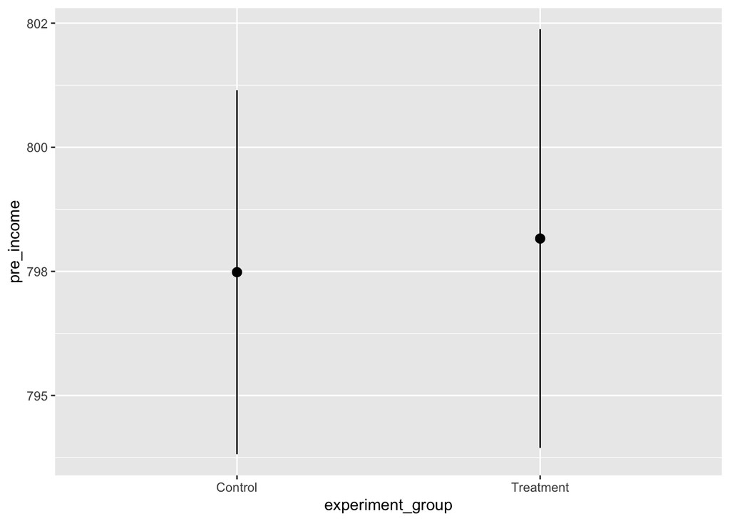

```r
ggplot(village_rct, aes(x = experiment_group, y = pre_income)) +
  stat_summary(fun.data = "mean_se")
```

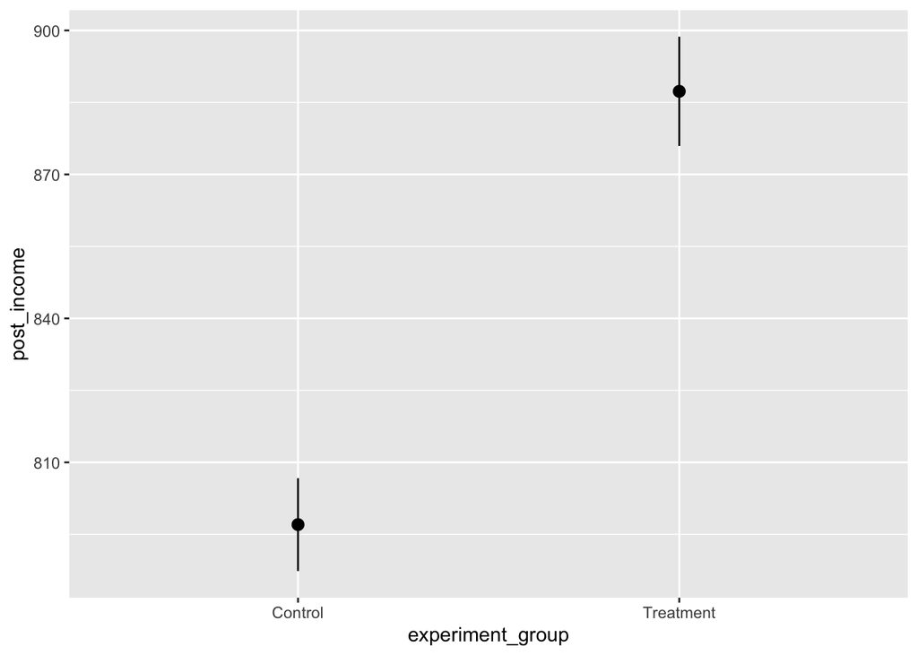

```r
ggplot(village_rct, aes(x = experiment_group, y = post_income)) +
  stat_summary(fun.data = "mean_se")
```

```r
model1 <- lm(post_income ~ experiment_group, data = village_rct)
tidy(model1)
```

| term | estimate | std.error | statistic | p.value |
| --- | --- | --- | --- | --- |
| (Intercept) | 797.0 | 9.76 | 81.65 | 0 |
| experiment_groupTreatment | 90.3 | 14.89 | 6.06 | 0 |

```r
glance(model1)
```

| r.squared | adj.r.squared | sigma | statistic | p.value | df | logLik | AIC | BIC | deviance | df.residual |
| --- | --- | --- | --- | --- | --- | --- | --- | --- | --- | --- |
| 0.029 | 0.028 | 261 | 36.8 | 0 | 2 | -8742 | 17489 | 17505 | 85052630 | 1250 |